# Comparative Advantage and Trade

October 17, 2018

## A brief aside on the opiod epidemic

“In 2016, nearly 64,000 people died of drug overdoses in America — with synthetic opioids (such as fentanyl), heroin, and common opioid painkillers (like Percocet and OxyContin) topping other causes of overdose, according to new data from the Centers for Disease Control and Prevention (CDC). **That’s a higher death toll than guns, car crashes, and HIV/AIDS ever killed in one year in the US, and a higher death toll than all US military casualties in the Vietnam and Iraq wars combined.**” - Vox

## How did it start?

- In the late 1990s / early 2000s doctors became very concerned about pain management.
- A few studies showed opioids such as oxycontin were less addictive than thought.
- Doctors began prescribing more, and were encouraged to prescribe more both by the medical establishment and by pharmaceutical companies.
- More studies found high rates of addiction and tolerance.
- Doctors stopped prescribing, patients who were addicted moved to illegal opioids.

## How does this relate to economics?

- We have limited resources, so as a society we decide what we value enough to dedicate resources to.
- Do we have a moral obligation to help opioid addicts who became addicted because of doctor prescriptions?
- Do we have a moral obligation to help opioid addicts who became addicted for some other reason?
- How does your stance change if this is someone in Pullman? In your dorm/apt? Your friend? Your family?

## How does this relate to economics?

- In-group / out-group behavior
- “Social distance”
- Which is more moral? Doing things out of duty or honor? Doing things because you want to be a good person?
- *How we build policy depends on how we value these things. Whether or not we support a UBI is determined more by these aspects than by logic or facts.*

## More information

- [Science VS podcast](https://www.gimletmedia.com/science-vs/opioids-how-america-got-hooked)
- [New York Times](https://www.nytimes.com/2017/10/26/us/opioid-crisis-public-health-emergency.html)
- [Vox](https://www.vox.com/science-and-health/2017/8/3/16079772/opioid-epidemic-drug-overdoses)

## Eye Bleach

[figure not shown]

Source: Reddit.

## A note on economic systems

There are two categories of economic systems:

- “Command and control” economies in which the state or a corporation decides how much to produce. There is not a market, but rather goods are distributed and work is demanded. Emphasizes “From each according to his ability, to each according to his needs” – Marx

(But Marx thought this would only be possible in a society where technology had removed the need for physical labor.)

- Market economies like the ones we are studying now.

## A note on economic systems

[figure not shown]

Source: unknown.

## It’s a great time to learn about trade!

[figure not shown]

Source: China Daily.

[A good practice video for trade thought experiments.](https://youtu.be/HneRNVtahYw)

## What we’ll talk about

- Why trade occurs.
- How it improves living standards.
- Ways that trade has lead to worse outcomes in some areas.

## What is good about trade

From Krugman and Wells:

- The key to a much better standard of living **for everyone** is trade.
- The reason we have an economy is that there are gains from trade.
- Gains from trade arise from specialization.

(But it’s **not** better for everyone… see [Autor, Dorn, Hanson (2016)](https://www.annualreviews.org/doi/abs/10.1146/annurev-economics-080315-015041), and a [video of Autor discussing his work](https://youtu.be/c07dcInoG0Y).)

## There are three important things to know about trade

- **Absolute Advantage** - A firm has an **absolute advantage** when they can produce more of a good than another firm, or when they can produce that good more efficiently. E.g. the U.S. produces some agricultural products such as corn very cheaply because corn is highly mechanized.
- **Comparative Advantage** - A firm has a **comparative advantage** if the *opportunity cost* is lower for that firm than for another.
- **Terms of Trade** - The exchange rate between two goods that facilitates trade between countries.

## Absolute advantage examples

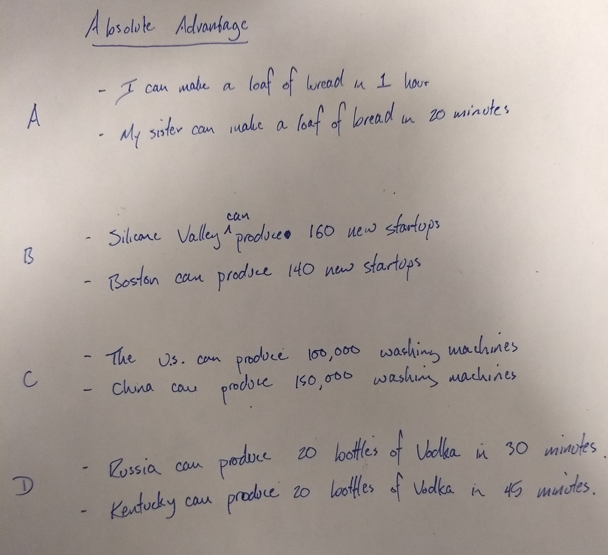

## Comparative advantage examples

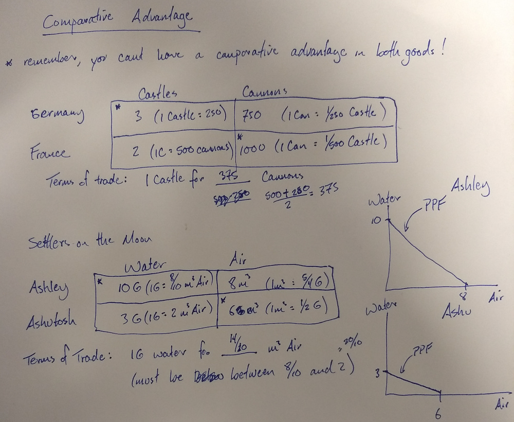

## Wrapping Up

- Complete the [knowledge check](https://goo.gl/forms/RBLnvYRWuN3NHYW52) for today’s participation point.
- Please provide [feedback](https://goo.gl/forms/8SiOwdi19kN8cINJ3) on today’s lecture.